# Season report: 4545 Season 9

[figure not shown]

### Overview

[figure not shown]

1st place

[Bad News Bishops](https://www.lichess4545.com/team4545/season/9/team/23/)

2nd place

[Stormy Knights](https://www.lichess4545.com/team4545/season/9/team/27/)

3rd place

[Scotch on the Rooks](https://www.lichess4545.com/team4545/season/9/team/8/)

| Gold | Silver | Bronze |
| --- | --- | --- |
| roso97 (9) | eie24 (8) | morallygray (8) |
| Napoleon_Solo (7) | PsiMaster (8) | SpiteKnight (8) |
| udaysatya (7) | rgpchesspe (8) | tnan123 (8) |
| rb52 (5) | be0wulf (5) | yago666 (8) |
| GetAGripWhitby (4) | gyrating_kairos (5) | deanmadden (4) |
| OuterHeaven92 (4) | deepblueincarnate (4) | revhas (4) |
| haggismcbean (1) | qrs (4) | mn8 (3) |
| iamjadetulip (1) | oignons (2) | ffenliv (1) |
| mn8 (1) | haggismcbean (1) | MMichael (1) |
| Plasterhippy (1) | Rascar_Capac (1) | nathanj439 (1) |

[output cut: 1 more lines]

#### Story of the season

[figure not shown]

#### Top of the boards

The top player performances by board (minimum 4 games played).[^3]

| Board | Player | Games | Points | Board Perf. |
| --- | --- | --- | --- | --- |
| 1 | lovlas | 7 | 6.5 | 2591.71428571429 |
| 1 | tomek188 | 7 | 5.5 | 2427.42857142857 |
| 1 | tipau | 7 | 5.5 | 2359.71428571429 |
| 1 | hetraie | 8 | 6 | 2353.25 |
| 1 | MeBeKa | 6 | 4.5 | 2351.33333333333 |
| 2 | Axp156 | 4 | 3.5 | 2281.5 |
| 2 | TMaus | 7 | 6 | 2262.71428571429 |
| 2 | morallygray | 6 | 4.5 | 2177.66666666667 |
| 2 | quirked | 7 | 5.5 | 2174.28571428571 |
| 2 | Lord_axe | 6 | 4 | 2127.16666666667 |

[output cut: 20 more lines]

### Game times / durations

#### When were games played?

[figure not shown]

#### How long did games take?

[figure not shown]

#### Longest games (moves)

*Includes games ranked at or above the 90th percentile by number of moves.*

| Rank | Players / Link | Date | Moves |
| --- | --- | --- | --- |
| 1 | Immortality - qrs | Thu 12 Oct 2017 | 119 |
| 2 | kobol - FelixNL | Sun 17 Sep 2017 | 105 |
| 3 | wardsstone - lovlas | Wed 27 Sep 2017 | 104 |
| 4 | Groundhopping - ErinYu | Sat 21 Oct 2017 | 95 |
| 5 | Lelouch_Vi_Brittania - MeBeKa | Thu 19 Oct 2017 | 89 |
| 6 | TMaus - oignons | Thu 7 Sep 2017 | 87 |
| 7 | fradtheimpaler - Mooserohde | Sat 23 Sep 2017 | 85 |
| 8 | CaptNCarter - matt_p_14 | Fri 22 Sep 2017 | 83 |
| 9 | eie24 - tomek188 | Sat 21 Oct 2017 | 81 |
| 10 | DracoxVitae - deepblueincarnate | Sun 1 Oct 2017 | 78 |

[output cut: 56 more lines]

#### Longest games

*Includes games ranked at or above the 90th percentile by total clock time.*[^4]

| Rank | Players / Link | Date | Total time |
| --- | --- | --- | --- |
| 1 | kobol - FelixNL | Sun 17 Sep 2017 | 3h 48m 36s |
| 2 | Immortality - qrs | Thu 12 Oct 2017 | 3h 35m 25s |
| 3 | TMaus - oignons | Thu 7 Sep 2017 | 3h 16m 37s |
| 4 | Groundhopping - ErinYu | Sat 21 Oct 2017 | 3h 12m 19s |
| 5 | wardsstone - lovlas | Wed 27 Sep 2017 | 3h 11m 5s |
| 6 | eie24 - tomek188 | Sat 21 Oct 2017 | 3h 10m 31s |
| 7 | Staincastle - Dmathman | Sat 30 Sep 2017 | 3h 6m 19s |
| 8 | Lelouch_Vi_Brittania - MeBeKa | Thu 19 Oct 2017 | 3h 5m 8s |
| 9 | Lichie - kobol | Sun 22 Oct 2017 | 3h 2m 14s |
| 10 | morallygray - Lord_axe | Sun 15 Oct 2017 | 3h 1m 40s |

[output cut: 56 more lines]

### By board / rating band

#### ACPL / blunder rate

[figure not shown]

#### Games with lowest combined ACPL

The games with the lowest combined ACPL (including draws).

| Board | Players / Link | Result | Sum ACPL | Date |
| --- | --- | --- | --- | --- |
| 1 | Sonata2 - ErinYu | 1/2-1/2 | 16 | Fri 27 Oct 2017 |
| 1 | badplayer_CM - lovlas | 0-1 | 16 | Thu 12 Oct 2017 |
| 2 | Axp156 - GnarlyGoat | 1/2-1/2 | 24 | Thu 19 Oct 2017 |
| 3 | Hackov - revoof | 1/2-1/2 | 19 | Fri 6 Oct 2017 |
| 4 | RuizBR - Dmathman | 1/2-1/2 | 20 | Thu 26 Oct 2017 |
| 5 | MichaelPren95 - SpiteKnight | 1/2-1/2 | 23 | Thu 28 Sep 2017 |
| 6 | qrs - flandoo | 0-1 | 31 | Thu 14 Sep 2017 |

#### Excl. draws

The *decisive* games with the lowest combined ACPL.

| Board | Players / Link | Result | Sum ACPL | Date |
| --- | --- | --- | --- | --- |
| 1 | badplayer_CM - lovlas | 0-1 | 16 | Thu 12 Oct 2017 |
| 2 | Pushedpawn - CaptNCarter | 0-1 | 27 | Sat 16 Sep 2017 |
| 3 | yago666 - pioki | 1-0 | 37 | Sat 21 Oct 2017 |
| 4 | GogoYubari - Wolf21 | 1-0 | 27 | Sun 29 Oct 2017 |
| 5 | Dmathman - dose7781 | 1-0 | 46 | Fri 22 Sep 2017 |
| 6 | qrs - flandoo | 0-1 | 31 | Thu 14 Sep 2017 |

### Openings - tables

#### Popular openings

All openings played in the season, excluding variations.

| Rank | Opening | Games | White % | 1-0 % | Draw % | 0-1 % | Mean Eval | Avg Rating |
| --- | --- | --- | --- | --- | --- | --- | --- | --- |
| 1 | Sicilian Defense | 80 | 41.25 | 32.5 | 17.5 | 50 | 0.316538461538462 | 1824.20625 |
| 2 | Caro-Kann Defense | 38 | 42.1052631578947 | 39.4736842105263 | 5.26315789473684 | 55.2631578947368 | -0.298947368421053 | 1751.13157894737 |
| 3 | French Defense | 37 | 50 | 43.2432432432432 | 13.5135135135135 | 43.2432432432432 | 0.218611111111111 | 1780.7972972973 |
| 4 | Indian Defense | 34 | 52.9411764705882 | 47.0588235294118 | 11.7647058823529 | 41.1764705882353 | 0.404705882352941 | 1850.79411764706 |
| 5 | Ruy Lopez | 33 | 43.9393939393939 | 39.3939393939394 | 9.09090909090909 | 51.5151515151515 | 0.963333333333333 | 1820.63636363636 |
| 6 | King's Indian Defense | 31 | 48.3870967741936 | 38.7096774193548 | 19.3548387096774 | 41.9354838709677 | 0.754838709677419 | 1840.37096774194 |
| 6 | Queen's Pawn Game | 31 | 50 | 38.7096774193548 | 22.5806451612903 | 38.7096774193548 | 0.442413793103448 | 1737.59677419355 |
| 7 | English Opening | 28 | 55.3571428571429 | 42.8571428571429 | 25 | 32.1428571428571 | 0.986296296296296 | 1870.26785714286 |
| 8 | Queen's Gambit Declined | 25 | 48 | 36 | 24 | 40 | 0.0372 | 1747.34 |
| 9 | Nimzo-Indian Defense | 23 | 58.695652173913 | 43.4782608695652 | 30.4347826086957 | 26.0869565217391 | 0.0872727272727273 | 1869.47826086957 |

[output cut: 49 more lines]

#### Popular variations

All openings played in the season, including variations.

| Rank | Opening | Games | White % | 1-0 % | Draw % | 0-1 % | Mean Eval | Avg Rating |
| --- | --- | --- | --- | --- | --- | --- | --- | --- |
| 1 | Indian Defense | 17 | 61.7647058823529 | 58.8235294117647 | 5.88235294117647 | 35.2941176470588 | 0.441764705882353 | 1878.94117647059 |
| 2 | Queen's Pawn Game: Mason Variation | 11 | 63.6363636363636 | 54.5454545454545 | 18.1818181818182 | 27.2727272727273 | 0.925555555555556 | 1684.27272727273 |
| 3 | Scandinavian Defense: Mieses-Kotroc Variation | 8 | 68.75 | 62.5 | 12.5 | 25 | 4.22625 | 1937.25 |
| 4 | Caro-Kann Defense | 6 | 50 | 50 | 0 | 50 | -0.39 | 1754.91666666667 |
| 4 | Pirc Defense | 6 | 50 | 50 | 0 | 50 | 3.97333333333333 | 1668.16666666667 |
| 4 | Sicilian Defense: Alapin Variation | 6 | 50 | 33.3333333333333 | 33.3333333333333 | 33.3333333333333 | -0.0483333333333333 | 1708.16666666667 |
| 4 | Sicilian Defense: Closed | 6 | 50 | 33.3333333333333 | 33.3333333333333 | 33.3333333333333 | -0.0916666666666667 | 1796.25 |
| 4 | Sicilian Defense: Modern Variations | 6 | 50 | 50 | 0 | 50 | -0.42 | 1610.75 |
| 5 | Italian Game: Classical Variation, Giuoco Pianissimo | 5 | 30 | 20 | 20 | 60 | -0.324 | 2105.8 |
| 5 | King's Indian Attack | 5 | 90 | 80 | 20 | 0 | 1.1 | 1723.6 |

[output cut: 346 more lines]

#### Best for White

The best-scoring main openings for White.

*Includes all main openings played in at least 10 games.*

| Rank | Opening | Games | White's score (%) | White wins (%) | Draws (%) | Black wins (%) | Mean eval after 15 moves | Avg rating |
| --- | --- | --- | --- | --- | --- | --- | --- | --- |
| 1 | Dutch Defense | 12 | 70.8333333333333 | 58.3333333333333 | 25 | 16.6666666666667 | 1.1625 | 1821.16666666667 |
| 2 | Scandinavian Defense | 20 | 62.5 | 50 | 25 | 25 | 1.803 | 1875.45 |
| 3 | Nimzo-Indian Defense | 23 | 58.695652173913 | 43.4782608695652 | 30.4347826086957 | 26.0869565217391 | 0.0872727272727273 | 1869.47826086957 |
| 4 | English Opening | 28 | 55.3571428571429 | 42.8571428571429 | 25 | 32.1428571428571 | 0.986296296296296 | 1870.26785714286 |
| 5 | Pirc Defense | 13 | 53.8461538461538 | 46.1538461538462 | 15.3846153846154 | 38.4615384615385 | 2.56615384615385 | 1833.19230769231 |
| 6 | Indian Defense | 34 | 52.9411764705882 | 47.0588235294118 | 11.7647058823529 | 41.1764705882353 | 0.404705882352941 | 1850.79411764706 |
| 7 | French Defense | 37 | 50 | 43.2432432432432 | 13.5135135135135 | 43.2432432432432 | 0.218611111111111 | 1780.7972972973 |
| 7 | Queen's Pawn Game | 31 | 50 | 38.7096774193548 | 22.5806451612903 | 38.7096774193548 | 0.442413793103448 | 1737.59677419355 |
| 7 | Slav Defense | 21 | 50 | 38.0952380952381 | 23.8095238095238 | 38.0952380952381 | 0.5195 | 1857.11904761905 |
| 8 | King's Indian Defense | 31 | 48.3870967741936 | 38.7096774193548 | 19.3548387096774 | 41.9354838709677 | 0.754838709677419 | 1840.37096774194 |

[output cut: 5 more lines]

#### Best for Black

The best-scoring main openings for Black.

*Includes all main openings played in at least 10 games.*

| Rank | Opening | Games | Black's score (%) | Black wins (%) | Draws (%) | White wins (%) | Mean eval after 15 moves | Avg rating |
| --- | --- | --- | --- | --- | --- | --- | --- | --- |
| 1 | Sicilian Defense | 80 | 58.75 | 50 | 17.5 | 32.5 | 0.316538461538462 | 1824.20625 |
| 2 | Caro-Kann Defense | 38 | 57.8947368421053 | 55.2631578947368 | 5.26315789473684 | 39.4736842105263 | -0.298947368421053 | 1751.13157894737 |
| 3 | Ruy Lopez | 33 | 56.0606060606061 | 51.5151515151515 | 9.09090909090909 | 39.3939393939394 | 0.963333333333333 | 1820.63636363636 |
| 4 | Italian Game | 18 | 52.7777777777778 | 44.4444444444444 | 16.6666666666667 | 38.8888888888889 | 1.67941176470588 | 1766.63888888889 |
| 5 | Queen's Gambit Declined | 25 | 52 | 40 | 24 | 36 | 0.0372 | 1747.34 |
| 6 | King's Indian Defense | 31 | 51.6129032258064 | 41.9354838709677 | 19.3548387096774 | 38.7096774193548 | 0.754838709677419 | 1840.37096774194 |
| 7 | French Defense | 37 | 50 | 43.2432432432432 | 13.5135135135135 | 43.2432432432432 | 0.218611111111111 | 1780.7972972973 |
| 7 | Queen's Pawn Game | 31 | 50 | 38.7096774193548 | 22.5806451612903 | 38.7096774193548 | 0.442413793103448 | 1737.59677419355 |
| 7 | Slav Defense | 21 | 50 | 38.0952380952381 | 23.8095238095238 | 38.0952380952381 | 0.5195 | 1857.11904761905 |
| 8 | Indian Defense | 34 | 47.0588235294118 | 41.1764705882353 | 11.7647058823529 | 47.0588235294118 | 0.404705882352941 | 1850.79411764706 |

[output cut: 5 more lines]

#### Popular gambits

All gambit openings played in the season.[^5]

| Rank | Name | Games | White score (%) |
| --- | --- | --- | --- |
| 1 | Smith-Morra Gambit | 6 | 16.6666666666667 |
| 2 | Benko Gambit | 5 | 80 |
| 3 | King's Gambit | 4 | 50 |
| 4 | Geller Gambit | 2 | 50 |
| 5 | Milner-Barry Gambit | 1 | 100 |
| 5 | Staunton Gambit | 1 | 100 |
| 6 | Urusov Gambit | 1 | 50 |
| 7 | Marshall Gambit | 1 | 0 |

#### Gambiteers

The players who enjoyed the most success when playing gambits.[^6]

*Shows all players who scored at least 50% playing gambits in the season (min. games: 2).*

| Rank | Player | Games | % Score |
| --- | --- | --- | --- |
| 1 | gatorricky | 2 | 75 |
| 2 | roso97 | 2 | 50 |
| 2 | TheRatRiverTrapper | 2 | 50 |

### Openings - sunburst

Click on the image below to see a sunburst plot of all openings played in the season.

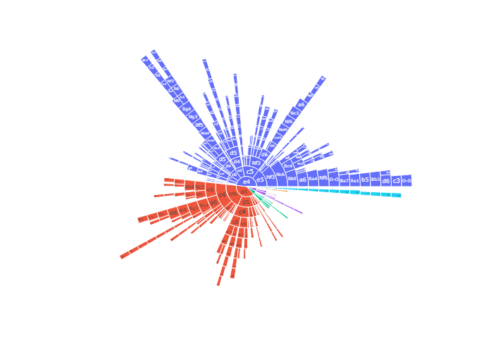